# Cyclistic Bike Sharing: 2021

Syed Amjad Ali

2023-01-06

## Introduction:

*Cyclistic* is fictional bike-sharing company based in Chicago. In my role as a junior data analyst I will solve the business task assigned to me by the Marketing Director, *How do annual members and casual riders use Cyclistic bikes differently?* I would do so by using the 6 Steps of Data Analysis learned throughout the course: Ask,Prepare,Process,Analyze, Share, and Act.

## Scenario

The director of marketing believes the company’s future success depends on maximizing the number of annual memberships. Therefore, my team wants to understand how casual riders and annual members use Cyclistic bikes differently. From these insights, my team will design a new marketing strategy to convert casual riders into annual members. In order for my recommendations to be approved, they must be backed up with compelling data insights and professional data visualizations.

## About the Company

In 2016, Cyclistic launched a successful bike-share offering. Since then, the program has grown to a fleet of 5,824 bicycles that are geotracked and locked into a network of 692 stations across Chicago. The bikes can be unlocked from one station and returned to any other station in the system anytime. Until now, Cyclistic’s marketing strategy relied on building general awareness and appealing to broad consumer segments. One approach that helped make these things possible was the flexibility of its pricing plans: single-ride passes, full-day passes, and annual memberships. Customers who purchase single-ride or full-day passes are referred to as casual riders. Customers who purchase annual memberships are Cyclistic members.

# 1.Ask

How do annual members and casual riders use Cyclistic bikes differently?

# 2.Prepare

I will use Cyclistic’s historical trip data to analyze and identify trends. I will download the data sets of the 12 months of 2021 from [here](https://divvy-tripdata.s3.amazonaws.com/index.html). The data has been made available by Motivate International Inc. under this [license](https://ride.divvybikes.com/data-license-agreement). The data follows ROCCC i.e.  
Reliable - YES, data is accurate, complete, and unbiased  
Original - YES, we can locate the original, public data source Comprehensive - YES, information is complete and extensive  
Current - YES, data is updated monthly  
Cited - YES

# 3.Process

I have chosen R to process and analyze the data due to several reasons. The data has hundreds of thousands of rows and many columns. R is very suitable for wrangling huge data sets such as this one, and also there is a large collection of packages that will help analyze the data more robustly.

**You can choose to hide or show code**

```r
library(tidyverse)
library(dplyr)
library(readr)
library(hms)
library(lubridate)
library(ggmap)
library(ggthemes)
```

**Loading the necessary packages**

```r
data_list <- list.files( pattern = "*.csv")  #There are 12 csv files in this directory for each of the months in 2021
df <- readr::read_csv(data_list, id = "file_name") #I am reading in the csv files for 12 months in a single data frame.

df<-df[order(as.Date(df$started_at, format="%Y-%m-%d")),] #sorted the date using the started at column

df<-df %>% select(-file_name,-ride_id,
                  -start_station_id,-end_station_id)#removing the file_name,ride_id columns,start id, end id

df$date <- as.Date(df$started_at) #The default format is yyyy-mm-dd
df$day <- format(as.Date(df$date), "%d")
df$month <- format(as.Date(df$date), "%m")
#df$year <- format(as.Date(df$date), "%Y")
df$day_of_week <- format(as.Date(df$date), "%A")
#Adding separate columns for day of week , month, etc
#this will help in our analysis later.

df$ride_length <- difftime(df$ended_at,df$started_at)
#ride_length column is the duration of a ride

#str(df) #checking for structure of all the coloumns


#is.factor(df$ride_length)
df$ride_length <-as.numeric(as.character(df$ride_length))
#conversion from factor to numeric to be able to perform calculations
#is.numeric(df$ride_length)

#So now lets clean the data even more
#Let's check for negative durations or any other
#unnessary data.

#df %>% count(ride_length<0,sort = TRUE)
#there seems to be 147 such cells.

df<- df[!(df$start_station_name == "HQ QR" |df$ride_length<0),] #removing negative ride_length and start station HQ QR, which is the times when the bikes were taken for
#servicing etc

df<-df[!(df$rideable_type=="docked_bike"),] #Removing docked bike, since the two main bike types are electric and classic

df<-na.omit(df) #getting rid of cells containing "na" values

# Notice that the days of the week are out of order. Let's fix that.
df$day_of_week <- ordered(df$day_of_week, levels=c("Sunday",
                 "Monday", "Tuesday", "Wednesday", "Thursday",
                 "Friday", "Saturday"))

df
```

```
## # A tibble: 4,276,142 × 15
##    rideable_type started_at          ended_at            start_station_name
##    <chr>         <dttm>              <dttm>              <chr>
##  1 electric_bike 2021-01-01 23:05:20 2021-01-01 23:28:01 2112 W Peterson Ave
##  2 electric_bike 2021-01-01 08:29:27 2021-01-01 08:39:30 Sedgwick St & North Ave
##  3 classic_bike  2021-01-01 17:02:08 2021-01-01 17:07:06 Clark St & Wrightwood …
##  4 classic_bike  2021-01-01 07:35:57 2021-01-01 07:44:10 Greenview Ave & Fuller…
##  5 classic_bike  2021-01-01 23:26:33 2021-01-02 00:26:08 St. Clair St & Erie St
##  6 electric_bike 2021-01-01 21:54:00 2021-01-01 22:02:37 Indiana Ave & Roosevel…
##  7 classic_bike  2021-01-01 11:54:22 2021-01-01 12:06:30 LaSalle Dr & Huron St
##  8 classic_bike  2021-01-01 10:44:29 2021-01-01 10:50:11 New St & Illinois St
##  9 classic_bike  2021-01-01 17:20:44 2021-01-01 17:39:56 Ritchie Ct & Banks St
## 10 classic_bike  2021-01-01 20:06:21 2021-01-01 20:14:30 Honore St & Division St
## # … with 4,276,132 more rows, and 11 more variables: end_station_name <chr>,
## #   start_lat <dbl>, start_lng <dbl>, end_lat <dbl>, end_lng <dbl>,
## #   member_casual <chr>, date <date>, day <chr>, month <chr>,
## #   day_of_week <ord>, ride_length <dbl>
```

# 4.Analyze

[figure not shown]

**Zoomed map of Chicago with some street names**

[figure not shown]

**Bike rental density during July**

[figure not shown]

**Bike rental density during December**

```r
summary(df$ride_length/60)#summary of ride_length in minutes
```

```
##    Min. 1st Qu.  Median    Mean 3rd Qu.    Max.
##    0.00    6.70   11.58   17.70   20.43 1499.90
```

**Standard summary of ride duration in minutes.**

```r
aggregate(df$ride_length/60 ~ df$member_casual, FUN = mean)
```

```
##   df$member_casual df$ride_length/60
## 1           casual          24.31616
## 2           member          13.18376
```

**The average ride duration in minutes for casual riders is 24.3 minutes, and for members is 13.18 minutes.**

```r
aggregate(df$ride_length/60 ~ df$member_casual +
            df$day_of_week, FUN = mean)
```

```
##    df$member_casual df$day_of_week df$ride_length/60
## 1            casual         Sunday          28.00182
## 2            member         Sunday          15.19426
## 3            casual         Monday          24.50974
## 4            member         Monday          12.72502
## 5            casual        Tuesday          21.89645
## 6            member        Tuesday          12.38767
## 7            casual      Wednesday          21.14453
## 8            member      Wednesday          12.45796
## 9            casual       Thursday          20.95771
## 10           member       Thursday          12.35363
## 11           casual         Friday          22.69618
## 12           member         Friday          12.79233
## 13           casual       Saturday          26.49182
## 14           member       Saturday          14.81946
```

**Average ride duration by day for members vs casual users**

```r
# analyze ridership data by type and weekday
df %>%
  mutate(weekday = wday(started_at, label = TRUE)) %>%  #creates weekday field using wday()
  group_by(member_casual, weekday) %>%  #groups by user type and weekday
  summarise(number_of_rides = n()                           #calculates the number of rides and average duration
            ,average_duration = mean(ride_length)) %>%      # calculates the average duration
  arrange(member_casual, weekday)
```

```
## # A tibble: 14 × 4
## # Groups:   member_casual [2]
##    member_casual weekday number_of_rides average_duration
##    <chr>         <ord>             <int>            <dbl>
##  1 casual        Sun              333414            1680.
##  2 casual        Mon              192514            1471.
##  3 casual        Tue              185330            1314.
##  4 casual        Wed              190528            1269.
##  5 casual        Thu              196549            1257.
##  6 casual        Fri              247986            1362.
##  7 casual        Sat              389971            1590.
##  8 member        Sun              311220             912.
##  9 member        Mon              346481             764.
## 10 member        Tue              388131             743.
## 11 member        Wed              397687             747.
## 12 member        Thu              373471             741.
## 13 member        Fri              365782             768.
## 14 member        Sat              357078             889.
```

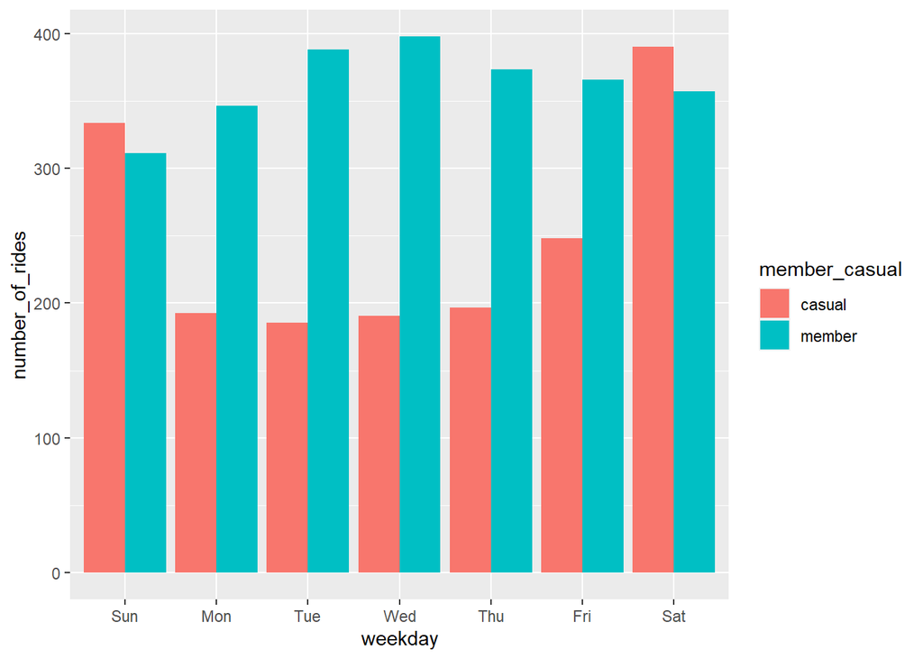

```r
# Let's visualize the number of rides by rider type per week day
df %>%
  mutate(weekday = wday(started_at, label = TRUE)) %>%
  group_by(member_casual, weekday) %>%
  summarise(number_of_rides = n()/1000,
            average_duration = mean(ride_length)) %>%
  arrange(member_casual, weekday)  %>%
  ggplot(aes(x = weekday, y = number_of_rides, fill = member_casual)) +
  geom_col(position = "dodge")
```

**The number of casual riders are more on weekends. The amount of member riders are consistent throughout the week, and a little less in the weekends.**

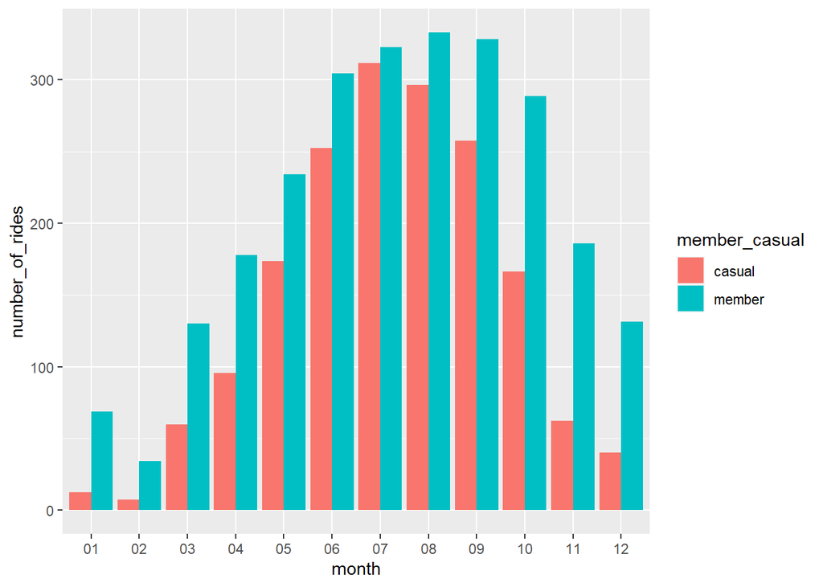

```r
#Let's visualize the number of rides by rider type per month
df %>%
  #mutate(weekday = wday(started_at, label = TRUE)) %>%
  group_by(member_casual, month) %>%
  summarise(number_of_rides = n()/1000,
            average_duration = mean(ride_length)) %>%
  arrange(member_casual, month)  %>%
  ggplot(aes(x = month, y = number_of_rides, fill = member_casual)) +
  geom_col(position = "dodge")
```

**The months of June through September see the highest volume of riders.**

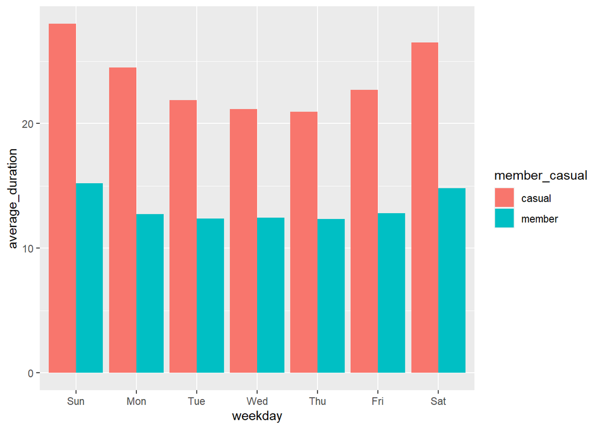

```r
# Let's create a visualization for average duration
df %>%
  mutate(weekday = wday(started_at, label = TRUE)) %>%
  group_by(member_casual, weekday) %>%
  summarise(number_of_rides = n()
            ,average_duration = mean(ride_length)/60) %>%
  arrange(member_casual, weekday)  %>%
  ggplot(aes(x = weekday, y = average_duration, fill = member_casual)) +
  geom_col(position = "dodge")
```

**Casual riders use the bikes for longer duration throughout the week.**

# 5.Share

During this phase, the results of my analysis can be shared with stakeholders, i.e. the Marketing Director, Cyclistic marketing analytics team and Cyclistic executive team.

# 6.Act

There are a few recommendations for the stakeholders involved. Since, according to my analysis, the number of members soar during the summer months(June to September) Cyclistic can offer attractive membership packages. These campaigns would be better of during the weekends, since weekends have the highest amount of casual riders. Moreover, extra benefits can be provided to the members, which in turn will attract more casual riders to convert to members.  
Furthermore, bike usage density represented in the city map will provided accurate suggestions about where to put billboards etc.

**Misc: We can add even more visuals with the help of map functions, to see the geolocations of the most used ride locations.**